### 1. Import Libraries

```python
!pip install missingno
```

```python
import numpy as np
import pandas as pd
import seaborn as sns
import missingno as msno
import matplotlib.pyplot as plt
import statsmodels
import statsmodels.api as sm

from sklearn.preprocessing import OneHotEncoder
from sklearn.preprocessing import StandardScaler
from sklearn.linear_model import LinearRegression
from sklearn.preprocessing import StandardScaler, MinMaxScaler


from scipy import stats
from scipy.stats import shapiro
from sklearn.model_selection import KFold, LeaveOneOut, GridSearchCV, cross_val_score, train_test_split
from statsmodels.graphics.gofplots import qqplot
from sklearn.metrics import mean_squared_error, mean_absolute_error,r2_score
from sklearn import metrics
```

### 2.Read Data

```python
data = pd.read_csv('train.csv')
```

```python
data.head()
```

|  | id | lib_mrq | lib_mod_doss | lib_mod | dscom | tvv | cod_cbr | hybride | puiss_admin_98 | puiss_max | ... | nox | hcnox | ptcl | masse_ordma_min | masse_ordma_max | champ_v9 | date_maj | Carrosserie | gamme | co2 |
| --- | --- | --- | --- | --- | --- | --- | --- | --- | --- | --- | --- | --- | --- | --- | --- | --- | --- | --- | --- | --- | --- |
| 0 | 0 | ALFA-ROMEO | 159 | 159 | 159 1750 Tbi (200ch) | 939AXN1B52C | ES | non | 11.781959 | 147.718483 | ... | 0.008077 | NaN | 0.002007 | 1503.476756 | 1499.424800 | 715/2007*692/2008EURO5 | mars-14 | BERLINE | MOY-SUPER | 181.192499 |
| 1 | 1 | ALFA-ROMEO | 159 | 159 | 159 1750 Tbi (200ch) | 939BXN1B53C | ES | non | 11.801943 | 146.442611 | ... | 0.023705 | NaN | 0.002014 | 1561.998814 | 1590.783523 | 715/2007*692/2008EURO5 | mars-14 | BERLINE | MOY-SUPER | 183.734067 |
| 2 | 2 | ALFA-ROMEO | 159 | 159 | 159 2.0 JTDm (136ch) | 939AXR1B64 | GO | non | 6.590252 | 95.501613 | ... | 0.183183 | 0.172804 | 0.001081 | 1575.302583 | 1543.988397 | 715/2007*692/2008EURO5 | mars-14 | BERLINE | MOY-SUPER | 131.893883 |
| 3 | 3 | ALFA-ROMEO | 159 | 159 | 159 2.0 JTDm (136ch) | 939AXR1B64B | GO | non | 6.756719 | 98.968186 | ... | 0.139350 | 0.174748 | 0.000988 | 1569.371476 | 1517.582931 | 715/2007*692/2008EURO5 | mars-14 | BERLINE | MOY-SUPER | 133.776897 |
| 4 | 5 | ALFA-ROMEO | 159 | 159 | 159 2.0 JTDm (170ch) | 939AXS1B66B | GO | non | 9.199929 | 122.730831 | ... | 0.191992 | 0.192432 | 0.000994 | 1572.424350 | 1585.093327 | 715/2007*692/2008EURO5 | mars-14 | BERLINE | MOY-SUPER | 141.761764 |

5 rows × 26 columns

```python
data.info()
```

```
<class 'pandas.core.frame.DataFrame'>
RangeIndex: 45788 entries, 0 to 45787
Data columns (total 26 columns):
 #   Column             Non-Null Count  Dtype
---  ------             --------------  -----
 0   id                 45788 non-null  int64
 1   lib_mrq            45788 non-null  object
 2   lib_mod_doss       45788 non-null  object
 3   lib_mod            45788 non-null  object
 4   dscom              45788 non-null  object
 5   tvv                45788 non-null  object
 6   cod_cbr            45788 non-null  object
 7   hybride            45788 non-null  object
 8   puiss_admin_98     45788 non-null  float64
 9   puiss_max          45788 non-null  float64
```

[output cut: 18 more lines]

### 3. Exploratory Data Analysis

## 3.1 Preparing the Dataset

# Renaming Columns

```python
data = data.rename(columns={
    'conso_exurb': 'conso_mixte',
    'conso_mixte': 'conso_exurb'
})
```

## 3.1.1 Data Dimensions

```python
data.shape
```

```
(45788, 26)
```

## 3.1.2 Data Types

```python
data.dtypes
```

```
id                     int64
lib_mrq               object
lib_mod_doss          object
lib_mod               object
dscom                 object
tvv                   object
cod_cbr               object
hybride               object
puiss_admin_98       float64
puiss_max            float64
typ_boite_nb_rapp     object
conso_urb            float64
conso_mixte          float64
conso_exurb          float64
co_typ_1             float64
hc                   float64
nox                  float64
hcnox                float64
ptcl                 float64
masse_ordma_min      float64
masse_ordma_max      float64
champ_v9              object
date_maj              object
Carrosserie           object
gamme                 object
co2                  float64
dtype: object
```

The dataset contains 12 object columns, 1 int column and 13 float columns

## 3.1.3 Missing Values

```python
missing_value = pd.DataFrame({
    'Missing Value': data.isnull().sum(),
    'Percentage': (data.isnull().sum() / len(data))*100
})
```

```python
missing_value.sort_values(by='Percentage', ascending=False)
```

|  | Missing Value | Percentage |
| --- | --- | --- |
| date_maj | 43161 | 94.262689 |
| hc | 37680 | 82.292304 |
| hcnox | 8153 | 17.805975 |
| ptcl | 2156 | 4.708657 |
| co_typ_1 | 82 | 0.179086 |
| nox | 82 | 0.179086 |
| champ_v9 | 11 | 0.024024 |
| conso_urb | 7 | 0.015288 |
| conso_mixte | 7 | 0.015288 |
| id | 0 | 0.000000 |
| gamme | 0 | 0.000000 |
| Carrosserie | 0 | 0.000000 |
| masse_ordma_max | 0 | 0.000000 |
| masse_ordma_min | 0 | 0.000000 |
| conso_exurb | 0 | 0.000000 |
| lib_mrq | 0 | 0.000000 |
| typ_boite_nb_rapp | 0 | 0.000000 |
| puiss_max | 0 | 0.000000 |
| puiss_admin_98 | 0 | 0.000000 |
| hybride | 0 | 0.000000 |
| cod_cbr | 0 | 0.000000 |
| tvv | 0 | 0.000000 |
| dscom | 0 | 0.000000 |
| lib_mod | 0 | 0.000000 |
| lib_mod_doss | 0 | 0.000000 |
| co2 | 0 | 0.000000 |

## 3.1.3.1 Data Cleaning

```python
for i in range(len(data)):
    if pd.isnull(data['hc'].values[i]) and pd.notnull(
            data['nox'].values[i]) and pd.notnull(data['hcnox'].values[i]):
        data['hc'].values[i] = data['hcnox'].values[i] - data['nox'].values[i]
    elif pd.isnull(data['nox'].values[i]) and pd.notnull(
            data['hc'].values[i]) and pd.notnull(data['hcnox'].values[i]):
        data['nox'].values[i] = data['hcnox'].values[i] - data['hc'].values[i]
    elif pd.isnull(data['hcnox'].values[i]) and pd.notnull(
            data['nox'].values[i]) and pd.notnull(data['hc'].values[i]):
           data['hcnox'].values[i] = data['hc'].values[i] + data['nox'].values[i]

data.dropna(subset=['hc', 'nox', 'hcnox'], how='all', inplace=True)
```

Hcnox=Hc+nox, I created a loop and filled in the missing values. I deleted the empty lines in every 3 lines.

```python
for i in range(len(data)):
    if 'V .' in str(data['typ_boite_nb_rapp'].values[i]):
        data['typ_boite_nb_rapp'].values[i] = data['typ_boite_nb_rapp'].values[i].replace('V .', 'V 0')

    if 'COMBISPCACE' in str(data['Carrosserie'].values[i]):
        data['Carrosserie'].values[i] = data['Carrosserie'].values[i].replace('COMBISPCACE', 'COMBISPACE')

    if 'MOY-INFERIEURE' in str(data['gamme'].values[i]):
        data['gamme'].values[i] = data['gamme'].values[i].replace('MOY-INFERIEURE', 'MOY-INFER')


print(data['gamme'].value_counts())
```

```
MOY-INFER     27842
MOY-SUPER     12531
LUXE           3000
SUPERIEURE     1279
INFERIEURE      858
ECONOMIQUE      196
Name: gamme, dtype: int64
```

```python
for i in range(len(data)):
    if '"' in str(data['champ_v9'].values[i]):
        data['champ_v9'].values[i] = data['champ_v9'].values[i].replace('"', '')

    if 'EURO' not in str(data['champ_v9'].values[i]) and '74EEV' not in str(
            data['champ_v9'].values[i]):
        data['champ_v9'].values[i] = 'null'

    if str(data['champ_v9'].values[i][-4:]) == "EURO":
        data['champ_v9'].values[i] = 'null'
data = data.replace('null', np.nan)
data.dropna(subset=['champ_v9'], inplace=True)

print(data['champ_v9'].value_counts())
```

```
715/2007*692/2008EURO5    20582
715/2007*195/2013EURO5    12938
715/2007*566/2011EURO5     4352
715/2007*630/2012EURO5     1820
715/2007*195/2013EURO6     1600
2005/55*2008/74EURO5       1523
2005/55*2008/74EEV         1508
595/2009*64/2012EURO6       492
715/2007*630/2012EURO6      404
715/2007*459/2012EURO5      311
715/2007*143/2013EURO6       90
715/2007*143/2013EURO5       37
715/2007*566/2011EURO6       15
715/2007*459/2012EURO6       12
Name: champ_v9, dtype: int64
```

```python
data.drop(['date_maj'], axis=1, inplace=True)
```

I deleted the 'date_maj' column

```python
data.drop(['lib_mod'], axis=1, inplace=True)
```

```python
data.drop(['lib_mod_doss'], axis=1, inplace=True)
```

lib_mod and lib_mod_doss contain the car model names. However, the 'gamme' variable already contains information about these tools, grouped into 6 separate groups.

```python
data.drop(['dscom'], axis=1, inplace=True)
```

```python
data.drop(['tvv'], axis=1, inplace=True)
```

```python
data.dropna(subset=["ptcl"], inplace=True)
```

```python
data["conso_mixte"].mean()
```

```
6.683572546228272
```

```python
data["conso_mixte"].fillna(data["conso_mixte"].mean(), inplace=True)
```

```python
data["conso_urb"].mean()
data["conso_urb"].fillna(data["conso_urb"].mean(), inplace=True)
```

Nan values in ptcl have been deleted.

```python
missing_value = pd.DataFrame({
    'Missing Value': data.isnull().sum(),
    'Percentage': (data.isnull().sum() / len(data))*100
})
```

```python
missing_value.sort_values(by='Percentage', ascending=False)
```

|  | Missing Value | Percentage |
| --- | --- | --- |
| id | 0 | 0.0 |
| hc | 0 | 0.0 |
| gamme | 0 | 0.0 |
| Carrosserie | 0 | 0.0 |
| champ_v9 | 0 | 0.0 |
| masse_ordma_max | 0 | 0.0 |
| masse_ordma_min | 0 | 0.0 |
| ptcl | 0 | 0.0 |
| hcnox | 0 | 0.0 |
| nox | 0 | 0.0 |
| co_typ_1 | 0 | 0.0 |
| lib_mrq | 0 | 0.0 |
| conso_exurb | 0 | 0.0 |
| conso_mixte | 0 | 0.0 |
| conso_urb | 0 | 0.0 |
| typ_boite_nb_rapp | 0 | 0.0 |
| puiss_max | 0 | 0.0 |
| puiss_admin_98 | 0 | 0.0 |
| hybride | 0 | 0.0 |
| cod_cbr | 0 | 0.0 |
| co2 | 0 | 0.0 |

No more missing values in this dataset.

## 3.1.3 Duplicate Data

```python
duplicate = data.duplicated().sum()
print('There are {} duplicated rows in the data'.format(duplicate))
```

```
There are 0 duplicated rows in the data
```

### 3.2 Data Understanding

## 3.2.1 Summary Statistics

```python
data.describe(include=np.number)
```

|  | id | puiss_admin_98 | puiss_max | conso_urb | conso_mixte | conso_exurb | co_typ_1 | hc | nox | hcnox | ptcl | masse_ordma_min | masse_ordma_max | co2 |
| --- | --- | --- | --- | --- | --- | --- | --- | --- | --- | --- | --- | --- | --- | --- |
| count | 43610.000000 | 43610.000000 | 43610.000000 | 43610.000000 | 43610.000000 | 43610.000000 | 43610.000000 | 43610.000000 | 43610.000000 | 43610.000000 | 43610.000000 | 43610.000000 | 43610.000000 | 43610.000000 |
| mean | 27754.396446 | 10.264622 | 116.526854 | 9.394284 | 6.683573 | 7.667587 | 0.174215 | 0.023526 | 0.311855 | 0.335379 | 0.000890 | 2118.803115 | 2366.703852 | 200.523564 |
| std | 15777.437411 | 4.267652 | 39.423874 | 1.554413 | 0.893129 | 1.095766 | 0.141266 | 0.023959 | 0.422239 | 0.417728 | 0.000987 | 270.059415 | 399.955237 | 28.969751 |
| min | 0.000000 | 2.798472 | 37.798751 | 2.749897 | 2.766431 | 3.013387 | -0.015107 | -0.806521 | -0.059940 | -0.034731 | -0.000184 | 851.649611 | 842.874809 | 69.181482 |
| 25% | 14094.250000 | 8.845870 | 98.106456 | 8.780916 | 6.512092 | 7.343737 | 0.060981 | 0.007630 | 0.186790 | 0.215090 | 0.000028 | 2003.115444 | 2108.727714 | 193.360214 |
| 50% | 27242.500000 | 9.656011 | 116.936918 | 9.440153 | 6.830161 | 7.800478 | 0.127240 | 0.022040 | 0.214174 | 0.238873 | 0.000972 | 2088.413645 | 2353.347995 | 204.953399 |
| 75% | 41807.750000 | 10.363977 | 121.427183 | 10.138308 | 7.177747 | 8.216170 | 0.282381 | 0.039644 | 0.239519 | 0.263845 | 0.001035 | 2262.307530 | 2746.784375 | 215.991373 |
| max | 54946.000000 | 80.029830 | 590.076404 | 25.663301 | 11.839297 | 16.414648 | 0.949664 | 0.143827 | 1.906954 | 1.921078 | 0.023142 | 2764.153256 | 3133.834775 | 381.310860 |

1.The average amount of CO2 emitted from cars is 200 g/km

2.Atleast 2.70 Litres of fuel is consumed be it the car is on city roads or highway.

3.In minimum fuel consumption; conso_urb < conso_mixte < conso_exurb,

In maximum fuel consumption; conso_urb > conso_exurb > conso_mixte

4.About 75% of the cars have 2262 or less a mass.

```python
data.describe(include = object).T
```

|  | count | unique | top | freq |
| --- | --- | --- | --- | --- |
| lib_mrq | 43610 | 41 | MERCEDES | 29120 |
| cod_cbr | 43610 | 7 | GO | 41056 |
| hybride | 43610 | 2 | non | 43371 |
| typ_boite_nb_rapp | 43610 | 13 | M 6 | 26183 |
| champ_v9 | 43610 | 14 | 715/2007*692/2008EURO5 | 19343 |
| Carrosserie | 43610 | 10 | MINIBUS | 37413 |
| gamme | 43610 | 6 | MOY-INFER | 27349 |

1.There are a total of 41 different car companies.

3.7 different types of fuels used by cars have been identifie and fuel GO seems to be the most famous.

4.Most cars are not hybrids

5.There are 6 types of range and the most is MOY-INFER.

## 3.2.2 Correlation

```python
data_num_features = data.select_dtypes(include=np.number)

print('The numerical columns in the dataset are: ',data_num_features.columns)
```

```
The numerical columns in the dataset are:  Index(['id', 'puiss_admin_98', 'puiss_max', 'conso_urb', 'conso_mixte',
       'conso_exurb', 'co_typ_1', 'hc', 'nox', 'hcnox', 'ptcl',
       'masse_ordma_min', 'masse_ordma_max', 'co2'],
      dtype='object')
```

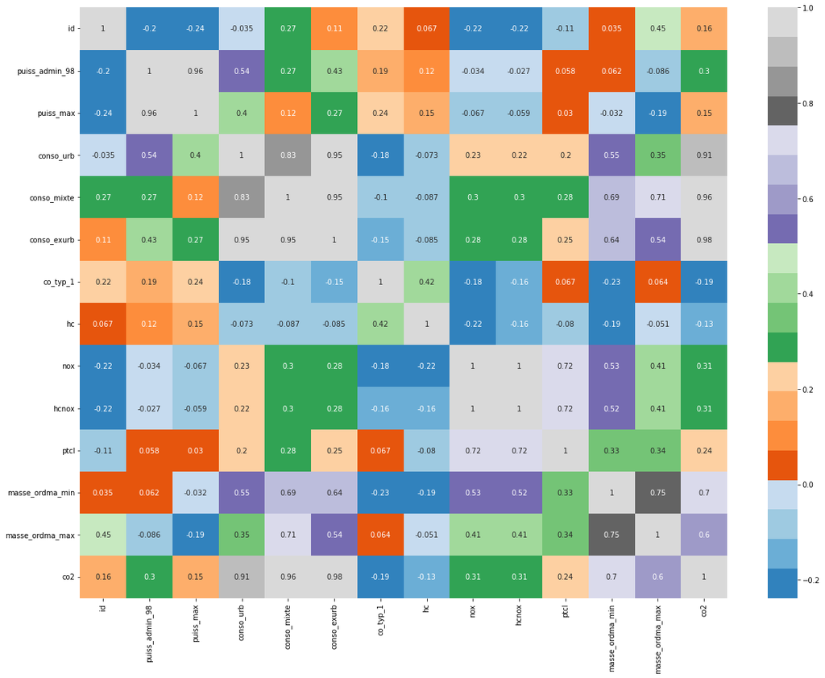

```python
plt.figure(figsize=(20,15))

corr_heatmap =  data_num_features.corr()

corr_heatmap = data_num_features.corr(method='pearson')
sns.heatmap(corr_heatmap, annot=True,cmap='tab20c')
plt.show()
```

2.Co2 has high positive correlation(>0.9) with conso_urb,conso_mixte and conso_exurb.

## 3.2.3 Analyse Categorical Variables

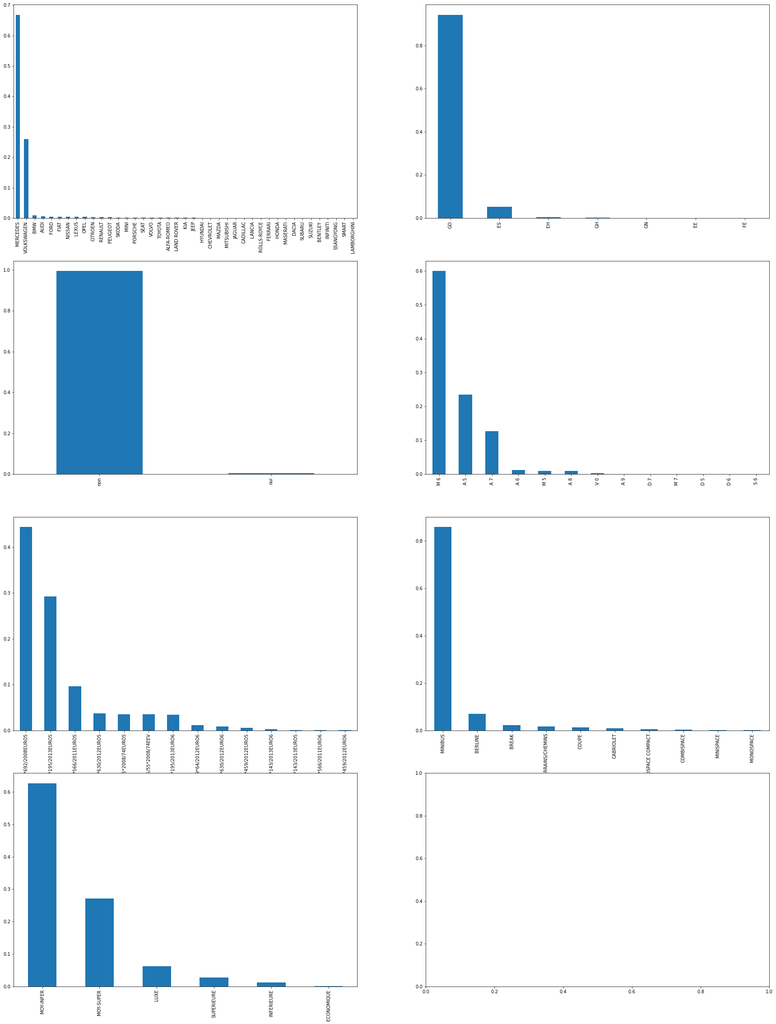

```python
fig, axes = plt.subplots(nrows=4, ncols=2, figsize=(30, 40))

data['lib_mrq'].value_counts(normalize=True).plot(kind='bar', ax=axes[0,0])
data['cod_cbr'].value_counts(normalize=True).plot(kind='bar', ax=axes[0,1])
data['hybride'].value_counts(normalize=True).plot(kind='bar', ax=axes[1,0])
data['typ_boite_nb_rapp'].value_counts(normalize=True).plot(kind='bar', ax=axes[1,1])
data['champ_v9'].value_counts(normalize=True).plot(kind='bar', ax=axes[2,0])
data['Carrosserie'].value_counts(normalize=True).plot(kind='bar', ax=axes[2,1])
data['gamme'].value_counts(normalize=True).plot(kind='bar', ax=axes[3,0])
```

## 3.2.4 Analyse Target Variable

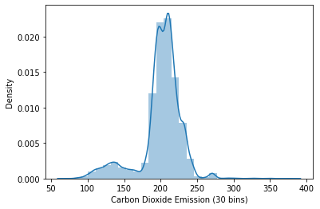

```python
sns.distplot(data['co2'], bins=30, kde=True, axlabel='Carbon Dioxide Emission (30 bins)');
plt.show()
```

```python
mean = data['co2'].mean()
mode = data['co2'].mode()
median = data['co2'].median()
```

```python
print(mean)
```

```
200.5235635590564
```

```python
print(mode)
```

```
0         69.181482
1         69.339539
2         70.284600
3         70.337646
4         80.100729
            ...
43605    350.909009
43606    351.684146
43607    378.947354
43608    380.942863
43609    381.310860
Name: co2, Length: 43610, dtype: float64
```

```python
print(median)
```

```
204.95339874811202
```

From the above histogram, we can see that co2 is moderately negatively skewed. mean < median < mode(there is no mode)

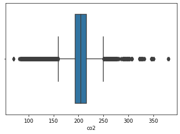

```python
sns.boxplot(x=data["co2"]);
```

## 3.2.5 Analyse Relationship between Target and Independent Variables

```python
data_cat_features = data.select_dtypes(include='object')
print('The categorical columns in the dataset are: ',data_cat_features.columns)
```

```
The categorical columns in the dataset are:  Index(['lib_mrq', 'cod_cbr', 'hybride', 'typ_boite_nb_rapp', 'champ_v9',
       'Carrosserie', 'gamme'],
      dtype='object')
```

```python
Carrosserie_co2 = data.groupby('Carrosserie')['co2'].mean().sort_values(ascending=False).head(10)
cod_cbr_co2 = data.groupby('cod_cbr')['co2'].mean().sort_values(ascending=False).head(10)
hybride_co2 = data.groupby('hybride')['co2'].mean().sort_values(ascending=False).head(10)
typ_boite_nb_rapp_co2 = data.groupby('typ_boite_nb_rapp')['co2'].mean().sort_values(ascending=False).head(10)
gamme_co2 = data.groupby('gamme')['co2'].mean().sort_values(ascending=False).head(10)
champ_v9_co2 = data.groupby('champ_v9')['co2'].mean().sort_values(ascending=False).head(10)
```

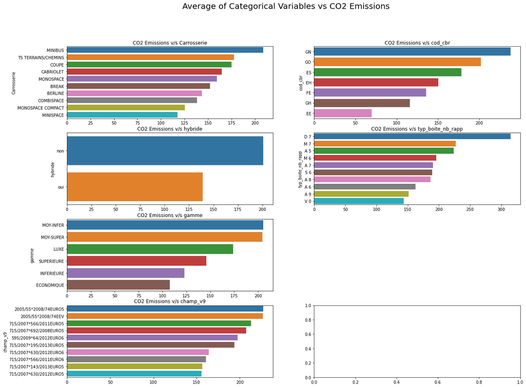

```python
fig, axes = plt.subplots(4,2, figsize=(20,15))
fig.suptitle('Average of Categorical Variables vs CO2 Emissions', size=20)

sns.barplot(ax=axes[0][0],x = Carrosserie_co2.values,y = Carrosserie_co2.index)
axes[0][0].set_title('CO2 Emissions v/s Carrosserie')

sns.barplot(ax=axes[0][1],x = cod_cbr_co2.values,y = cod_cbr_co2.index)
axes[0][1].set_title('CO2 Emissions v/s cod_cbr')

sns.barplot(ax=axes[1][0],x = hybride_co2.values,y = hybride_co2.index)
axes[1][0].set_title('CO2 Emissions v/s hybride')

sns.barplot(ax=axes[1][1], x=typ_boite_nb_rapp_co2.values,y=typ_boite_nb_rapp_co2.index)
axes[1][1].set_title('CO2 Emissions v/s typ_boite_nb_rapp')

sns.barplot(ax=axes[2][0],x = gamme_co2.values,y = gamme_co2.index)
axes[2][0].set_title('CO2 Emissions v/s gamme')

sns.barplot(ax=axes[3][0],x = champ_v9_co2.values,y = champ_v9_co2.index)
axes[3][0].set_title('CO2 Emissions v/s champ_v9')



fig.delaxes(axes[2][1])
plt.show()
```

# Relationship between masse_ordma_min and CO2 Emissions

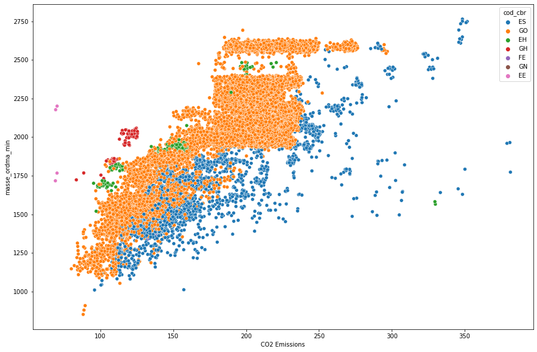

```python
plt.rcParams["figure.figsize"] = (15,10)
sns.scatterplot('co2','masse_ordma_min',data = data,hue='cod_cbr')
plt.xlabel("CO2 Emissions", fontsize=10)
plt.ylabel("masse_ordma_min", fontsize=10)
plt.show()
```

# Relationship between conso_mixte and CO2 Emissions

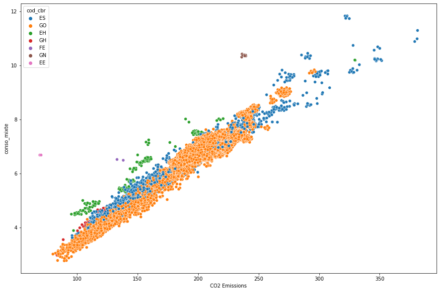

```python
plt.rcParams["figure.figsize"] = (15,10)
sns.scatterplot('co2','conso_mixte',data = data,hue='cod_cbr')
plt.xlabel("CO2 Emissions", fontsize=10)
plt.ylabel("conso_mixte", fontsize=10)
plt.show()
```

```python
#Relationship between masse_ordma_max and CO2 Emissions
```

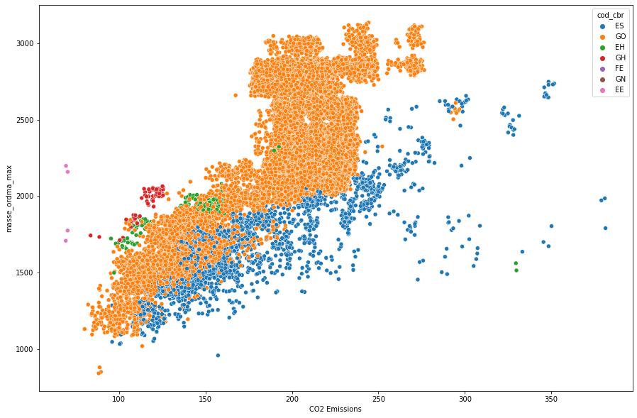

```python
plt.rcParams["figure.figsize"] = (15,10)
sns.scatterplot('co2','masse_ordma_max',data = data,hue='cod_cbr')
plt.xlabel("CO2 Emissions", fontsize=10)
plt.ylabel("masse_ordma_max", fontsize=10)
plt.show()
```

## 3.2.6 Feature Engineering

```python
data['gamme'].value_counts()
```

```
MOY-INFER     27349
MOY-SUPER     11807
LUXE           2696
SUPERIEURE     1213
INFERIEURE      517
ECONOMIQUE       28
Name: gamme, dtype: int64
```

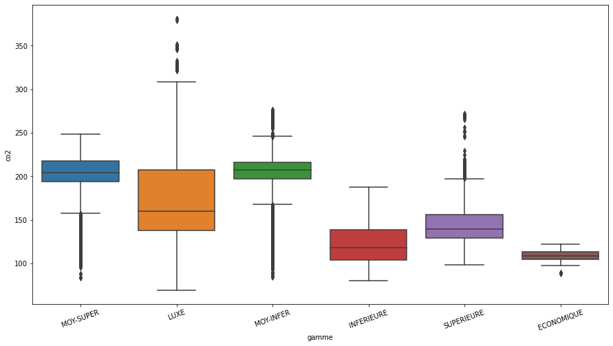

```python
plt.figure(figsize=(15,8))
ax = sns.boxplot(x="gamme", y="co2", data=data)
ax.set_xticklabels(labels=ax.get_xticklabels(), rotation=20)
plt.show()
```

```python
data['Carrosserie'].value_counts()
```

```
MINIBUS                37413
BERLINE                 3037
BREAK                    952
TS TERRAINS/CHEMINS      753
COUPE                    570
CABRIOLET                364
MONOSPACE COMPACT        252
COMBISPACE               163
MINISPACE                 54
MONOSPACE                 52
Name: Carrosserie, dtype: int64
```

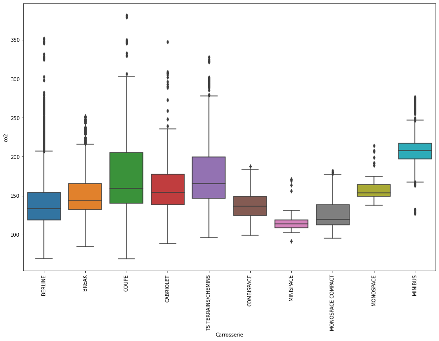

```python
plt.figure(figsize=(15,10))
ax = sns.boxplot(x="Carrosserie", y="co2", data=data)
ax.set_xticklabels(labels=ax.get_xticklabels(), rotation=90)
plt.show()
```

```python
data['lib_mrq'].value_counts()
```

```
MERCEDES       29120
VOLKSWAGEN     11340
BMW              392
AUDI             287
FORD             232
FIAT             228
NISSAN           215
LEXUS            204
OPEL             200
CITROEN          140
RENAULT          113
PEUGEOT          107
SKODA             93
MINI              92
PORSCHE           88
SEAT              85
VOLVO             82
TOYOTA            68
ALFA-ROMEO        63
LAND ROVER        48
KIA               47
JEEP              43
HYUNDAI           35
CHEVROLET         34
MAZDA             30
MITSUBISHI        30
JAGUAR            27
CADILLAC          25
LANCIA            21
ROLLS-ROYCE       19
FERRARI           15
HONDA             15
MASERATI          15
DACIA             13
SUBARU            10
SUZUKI             9
BENTLEY            9
INFINITI           6
SSANGYONG          6
SMART              3
LAMBORGHINI        1
Name: lib_mrq, dtype: int64
```

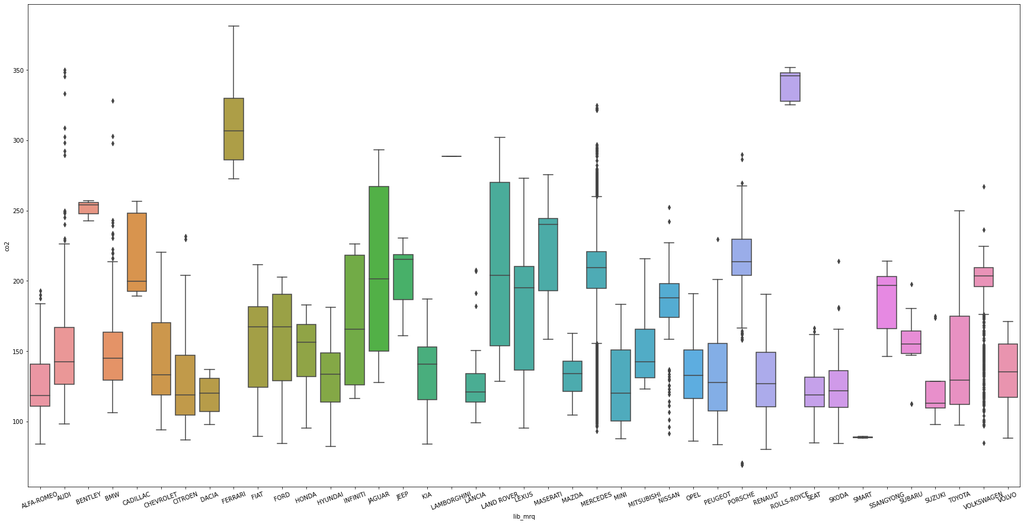

```python
plt.figure(figsize=(30,15))
ax = sns.boxplot(x="lib_mrq", y="co2", data=data)
ax.set_xticklabels(labels=ax.get_xticklabels(), rotation=20)
plt.show()
```

```python
data['cod_cbr'].value_counts()
```

```
GO    41056
ES     2306
EH      166
GH       69
GN        7
EE        4
FE        2
Name: cod_cbr, dtype: int64
```

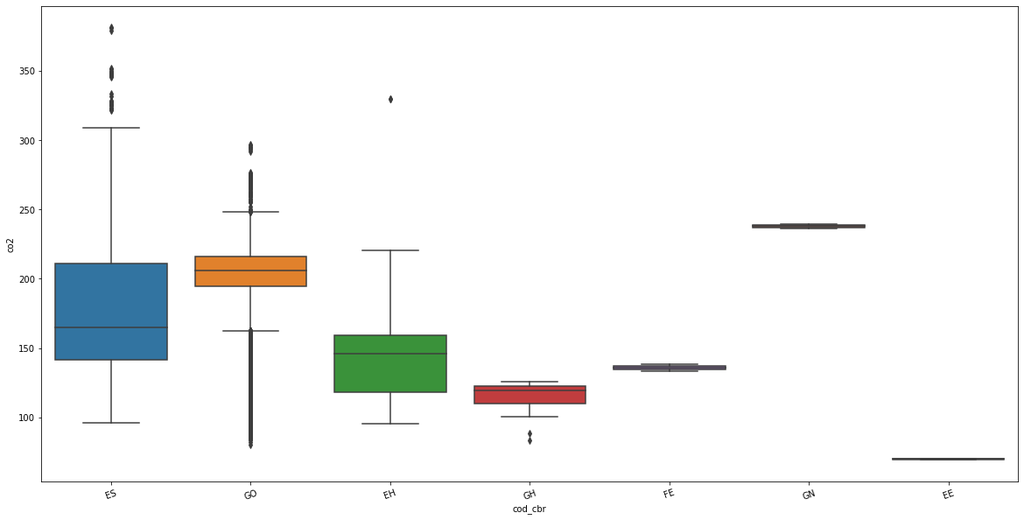

```python
plt.figure(figsize=(20,10))
ax = sns.boxplot(x="cod_cbr", y="co2", data=data)
ax.set_xticklabels(labels=ax.get_xticklabels(), rotation=20)
plt.show()
```

```python
data['hybride'].value_counts()
```

```
non    43371
oui      239
Name: hybride, dtype: int64
```

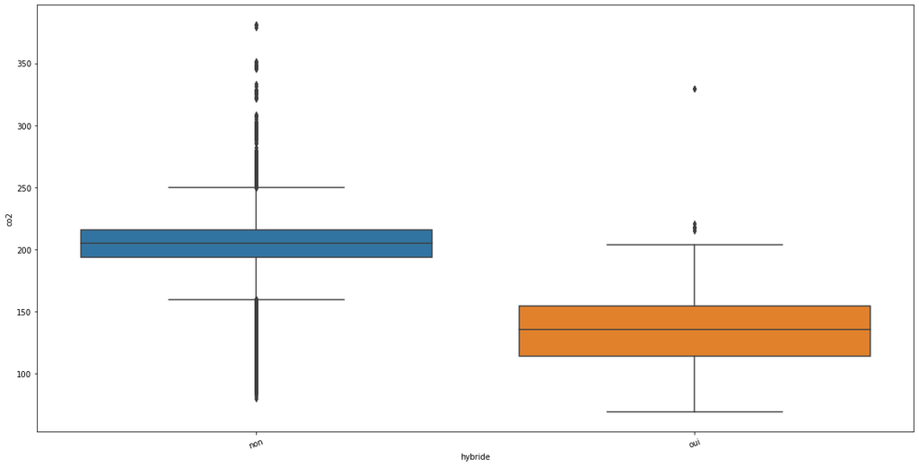

```python
plt.figure(figsize=(20,10))
ax = sns.boxplot(x="hybride", y="co2", data=data)
ax.set_xticklabels(labels=ax.get_xticklabels(), rotation=20)
plt.show()
```

```python
data['Carrosserie_type'] = data['Carrosserie'].replace(['BERLINE','BREAK','TS TERRAINS/CHEMINS','COUPE', 'CABRIOLET'],'TYPES_AUTRES')
data['Carrosserie_type'] = data['Carrosserie_type'].replace(['MONOSPACE COMPACT', 'COMBISPACE', 'MINISPACE','MONOSPACE'], 'TYPES_SPACE')
data['Carrosserie_type'] = data['Carrosserie_type'].replace(['MINIBUS'],'TYPES_MINIBUS')
```

```python
data.drop(['Carrosserie'], inplace=True, axis=1)
data['Carrosserie_type'].unique()
```

```
array(['TYPES_AUTRES', 'TYPES_SPACE', 'TYPES_MINIBUS'], dtype=object)
```

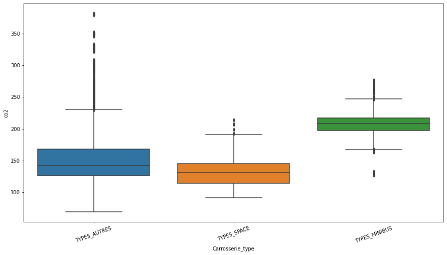

```python
plt.figure(figsize=(15,8))
ax = sns.boxplot(x="Carrosserie_type", y="co2", data=data)
ax.set_xticklabels(labels=ax.get_xticklabels(), rotation=20)
plt.show()
```

```python
data['lib_mrq_new'] = data['lib_mrq'].replace(['BMW','AUDI','FORD','FIAT','NISSAN','LEXUS','OPEL','CITROEN','RENAULT','PEUGEOT','SKODA','MINI','PORSCHE','SEAT','VOLVO','TOYOTA','ALFA-ROMEO',
                                              'LAND ROVER','KIA','JEEP','HYUNDAI','CHEVROLET','MAZDA','MITSUBISHI','JAGUAR','CADILLAC','LANCIA','ROLLS-ROYCE',
                                              'FERRARI','HONDA','MASERATI','DACIA','SUBARU','SUZUKI','BENTLEY','INFINITI','SSANGYONG','SMART','LAMBORGHINI',
                                              'ASTON MARTIN','LADA','LOTUS'],'Marque_Autres')
data['lib_mrq_new'] = data['lib_mrq_new'].replace(['MERCEDES'], 'Mercedes')
data['lib_mrq_new'] = data['lib_mrq_new'].replace(['VOLKSWAGEN'],'Volkswagen')
```

```python
data.drop(['lib_mrq'], inplace=True, axis=1)
data['lib_mrq_new'].unique()
```

```
array(['Marque_Autres', 'Mercedes', 'Volkswagen'], dtype=object)
```

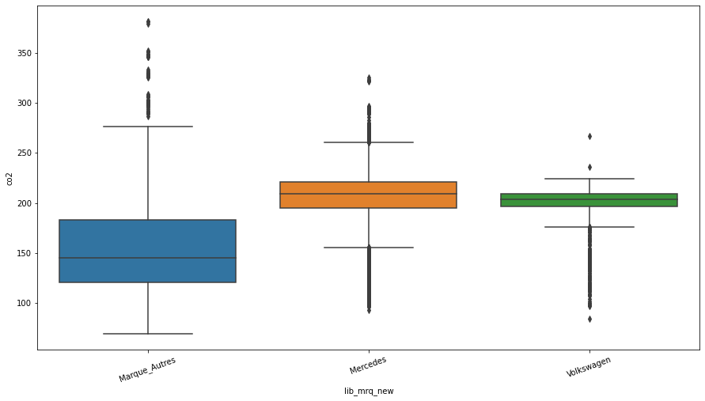

```python
plt.figure(figsize=(15,8))
ax = sns.boxplot(x="lib_mrq_new", y="co2", data=data)
ax.set_xticklabels(labels=ax.get_xticklabels(), rotation=20)
plt.show()
```

### 4.1 Outliers

## 4.1.1 Discovery of Outliers

```python
df_num_features=data.select_dtypes(include=np.number)
```

# Identifying outliers using IQR

```python
Q1 = df_num_features.quantile(0.25)
Q3 = df_num_features.quantile(0.75)
IQR = Q3 - Q1
print(IQR)
```

```
id                 27713.500000
puiss_admin_98         1.518107
puiss_max             23.320727
conso_urb              1.357392
conso_mixte            0.665655
conso_exurb            0.872432
co_typ_1               0.221399
hc                     0.032014
nox                    0.052729
hcnox                  0.048755
ptcl                   0.001007
masse_ordma_min      259.192086
masse_ordma_max      638.056662
co2                   22.631159
dtype: float64
```

```python
outlier = pd.DataFrame((df_num_features < (Q1 - 1.5 * IQR)) | (df_num_features > (Q3 + 1.5 * IQR)))

for i in outlier.columns:
    print('Total number of Outliers in column {} are {}'.format(i, (len(outlier[outlier[i] == True][i]))))
```

```
Total number of Outliers in column id are 0
Total number of Outliers in column puiss_admin_98 are 5782
Total number of Outliers in column puiss_max are 4052
Total number of Outliers in column conso_urb are 4036
Total number of Outliers in column conso_mixte are 5407
Total number of Outliers in column conso_exurb are 4537
Total number of Outliers in column co_typ_1 are 115
Total number of Outliers in column hc are 328
Total number of Outliers in column nox are 6799
Total number of Outliers in column hcnox are 6959
Total number of Outliers in column ptcl are 2788
Total number of Outliers in column masse_ordma_min are 2742
Total number of Outliers in column masse_ordma_max are 85
Total number of Outliers in column co2 are 4840
```

# Visualizing outliers using Boxplots

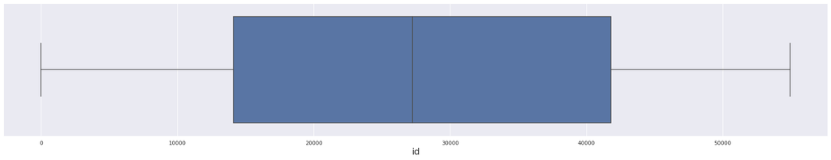

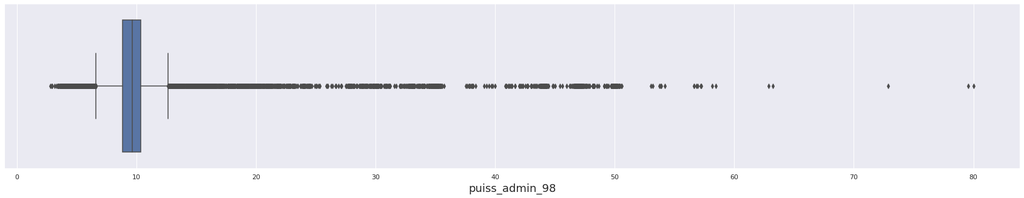

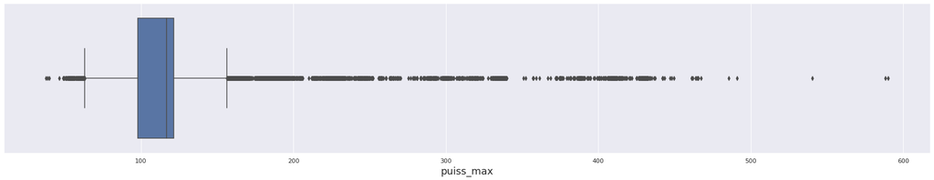

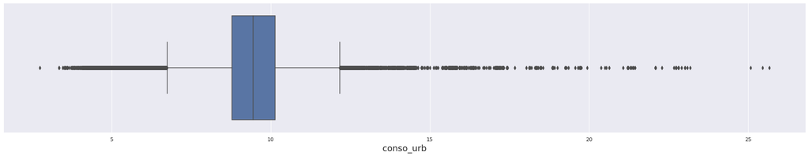

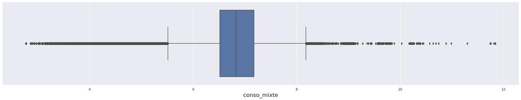

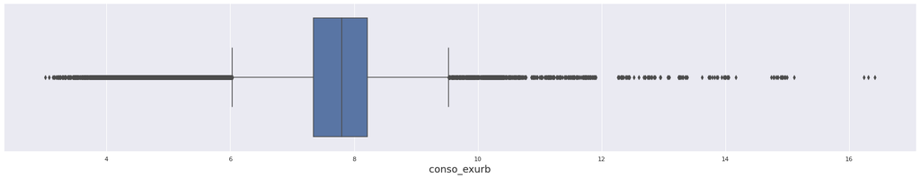

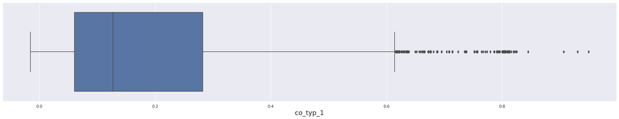

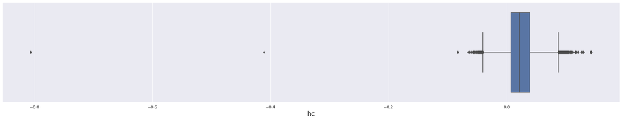

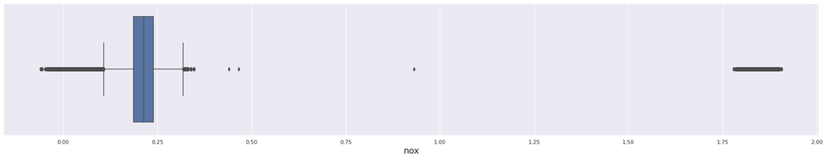

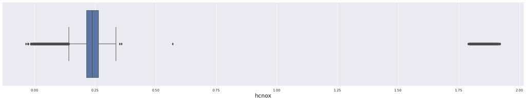

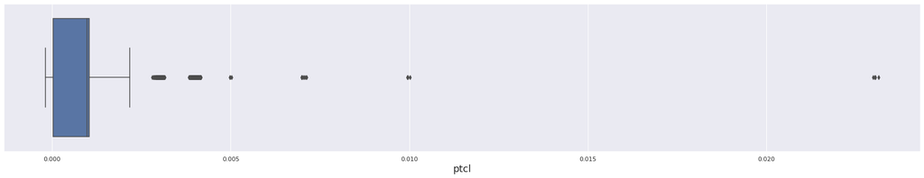

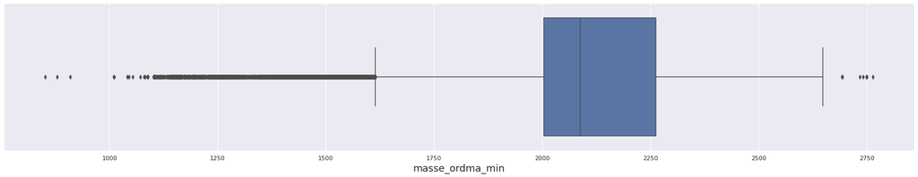

[2 more figures not shown]

```python
for column in enumerate(df_num_features):
    plt.figure(figsize=(30,5))
    sns.set_theme(style="darkgrid")
    sns.boxplot(x=column[1], data=  df_num_features)
    plt.xlabel(column[1],fontsize=18)
    plt.show()
```

## 4.1.2 Removal of Outliers

# Checking the normality of numeric features

```python
stat, p_value = shapiro(df_num_features)

print('Test statistic:', stat)
print('P-Value:', p_value)
```

```
Test statistic: 0.3053783178329468
P-Value: 0.0
```

Since the numeric features are not normal we are removing the outliers using IQR method

```python
data = data[~((data < (Q1 - 1.5 * IQR)) |(data > (Q3 + 1.5 * IQR))).any(axis=1)]
data.reset_index(inplace=True, drop=True)
```

```python
##4.1.3 Re-checking Correlation
```

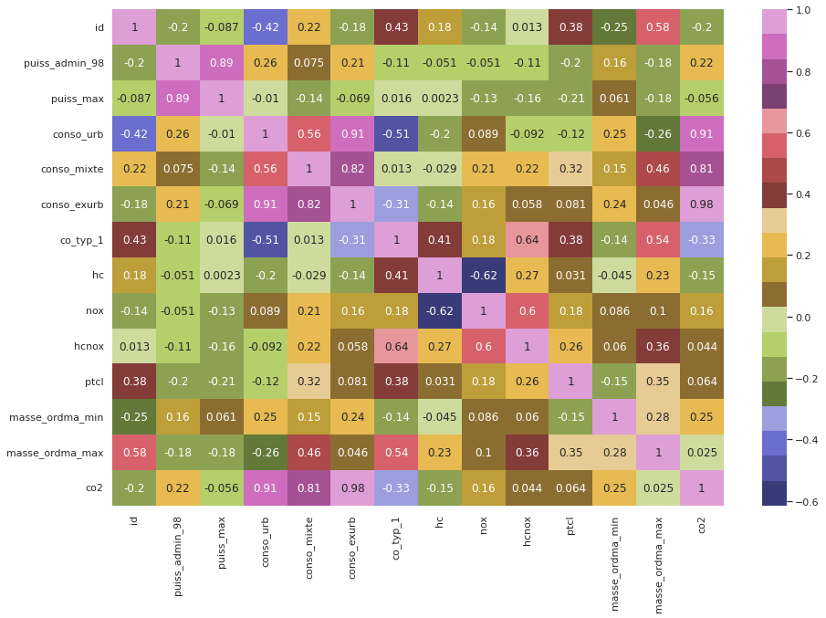

```python
data_num_features = data.select_dtypes(include=np.number)

corr =  data_num_features.corr()

corr =data_num_features.corr(method='pearson')
sns.heatmap(corr, annot=True,cmap='tab20b')
plt.show()
```

```python
for col in data_num_features:
    highest_corr_values = abs(data.corr()[col]).nlargest(n=5) # 5 values with the highest correlation
    print(highest_corr_values)
   # print if value greater than 0.75.
    for index, value in highest_corr_values.items():
        if 1> value >=0.75:
            print(index, col, "variables have high correlation: ", value)
```

```
id                 1.000000
masse_ordma_max    0.580033
co_typ_1           0.431411
conso_urb          0.421399
ptcl               0.378227
Name: id, dtype: float64
puiss_admin_98    1.000000
puiss_max         0.885163
conso_urb         0.257775
co2               0.220284
conso_exurb       0.207513
Name: puiss_admin_98, dtype: float64
puiss_max puiss_admin_98 variables have high correlation:  0.8851627838187918
puiss_max          1.000000
puiss_admin_98     0.885163
ptcl               0.210420
masse_ordma_max    0.177866
hcnox              0.160716
Name: puiss_max, dtype: float64
puiss_admin_98 puiss_max variables have high correlation:  0.8851627838187918
conso_urb      1.000000
co2            0.914948
conso_exurb    0.905403
conso_mixte    0.556806
co_typ_1       0.511889
Name: conso_urb, dtype: float64
co2 conso_urb variables have high correlation:  0.9149481487308548
conso_exurb conso_urb variables have high correlation:  0.9054025152995362
conso_mixte        1.000000
conso_exurb        0.819107
co2                0.806240
conso_urb          0.556806
masse_ordma_max    0.462260
Name: conso_mixte, dtype: float64
conso_exurb conso_mixte variables have high correlation:  0.8191065988569126
co2 conso_mixte variables have high correlation:  0.8062401119751685
conso_exurb    1.000000
co2            0.980357
conso_urb      0.905403
conso_mixte    0.819107
```

[output cut: 41 more lines]

```
masse_ordma_max    1.000000
id                 0.580033
co_typ_1           0.541913
conso_mixte        0.462260
hcnox              0.359545
Name: masse_ordma_max, dtype: float64
co2            1.000000
conso_exurb    0.980357
conso_urb      0.914948
conso_mixte    0.806240
co_typ_1       0.330152
Name: co2, dtype: float64
conso_exurb co2 variables have high correlation:  0.9803574528286324
conso_urb co2 variables have high correlation:  0.9149481487308548
conso_mixte co2 variables have high correlation:  0.8062401119751685
```

```python
data= data.drop(['conso_exurb'], axis=1)
```

## 4.2 Categorical Encoding

```python
data_cat_features = data.select_dtypes(include='object')
print('The categorical columns in the dataset are: ',data_cat_features.columns)
```

```
The categorical columns in the dataset are:  Index(['cod_cbr', 'hybride', 'typ_boite_nb_rapp', 'champ_v9', 'gamme',
       'Carrosserie_type', 'lib_mrq_new'],
      dtype='object')
```

```python
df_dummies = pd.get_dummies(data = data[['cod_cbr', 'hybride', 'typ_boite_nb_rapp', 'champ_v9', 'gamme',
       'Carrosserie_type', 'lib_mrq_new']])

df_num_features=data.select_dtypes(include=np.number)

df_comb = pd.concat([df_num_features, df_dummies], axis = 1)
```

```python
df_comb.head()
```

|  | id | puiss_admin_98 | puiss_max | conso_urb | conso_mixte | co_typ_1 | hc | nox | hcnox | ptcl | ... | gamme_LUXE | gamme_MOY-INFER | gamme_MOY-SUPER | gamme_SUPERIEURE | Carrosserie_type_TYPES_AUTRES | Carrosserie_type_TYPES_MINIBUS | Carrosserie_type_TYPES_SPACE | lib_mrq_new_Marque_Autres | lib_mrq_new_Mercedes | lib_mrq_new_Volkswagen |
| --- | --- | --- | --- | --- | --- | --- | --- | --- | --- | --- | --- | --- | --- | --- | --- | --- | --- | --- | --- | --- | --- |
| 0 | 541 | 12.163598 | 149.033383 | 8.254154 | 6.445448 | 0.269281 | 0.009171 | 0.168968 | 0.178140 | -0.000022 | ... | 1 | 0 | 0 | 0 | 1 | 0 | 0 | 1 | 0 | 0 |
| 1 | 1148 | 10.459728 | 119.464710 | 10.749563 | 6.667877 | 0.147380 | 0.037621 | 0.138731 | 0.176352 | -0.000030 | ... | 0 | 0 | 1 | 0 | 1 | 0 | 0 | 1 | 0 | 0 |
| 2 | 1149 | 10.865686 | 119.379356 | 10.723620 | 6.694772 | 0.138285 | -0.019375 | 0.192442 | 0.173067 | 0.000070 | ... | 0 | 0 | 1 | 0 | 1 | 0 | 0 | 1 | 0 | 0 |
| 3 | 1150 | 10.081297 | 119.223663 | 8.235397 | 5.563086 | 0.232968 | 0.059341 | 0.130272 | 0.189613 | 0.000014 | ... | 0 | 0 | 1 | 0 | 1 | 0 | 0 | 1 | 0 | 0 |
| 4 | 1151 | 10.000860 | 119.369760 | 8.138611 | 5.634236 | 0.252186 | 0.054562 | 0.133331 | 0.187893 | -0.000018 | ... | 0 | 0 | 1 | 0 | 1 | 0 | 0 | 1 | 0 | 0 |

5 rows × 40 columns

```python
df_comb.info()
```

```
<class 'pandas.core.frame.DataFrame'>
RangeIndex: 31323 entries, 0 to 31322
Data columns (total 40 columns):
 #   Column                           Non-Null Count  Dtype
---  ------                           --------------  -----
 0   id                               31323 non-null  int64
 1   puiss_admin_98                   31323 non-null  float64
 2   puiss_max                        31323 non-null  float64
 3   conso_urb                        31323 non-null  float64
 4   conso_mixte                      31323 non-null  float64
 5   co_typ_1                         31323 non-null  float64
 6   hc                               31323 non-null  float64
 7   nox                              31323 non-null  float64
 8   hcnox                            31323 non-null  float64
 9   ptcl                             31323 non-null  float64
```

[output cut: 32 more lines]

### 5. Multiple Linear Regression Models

```python
X = df_comb.drop(['co2'], axis=1)
y = df_comb['co2']
```

```python
X = sm.add_constant(X)
```

```python
X_train, X_test, y_train, y_test = train_test_split(X, y, test_size=20, random_state=10)
```

```python
MLR_model1 = sm.OLS(y_train, X_train).fit()
MLR_model1.summary()
```

OLS Regression Results

| Dep. Variable: | co2 | R-squared: | 0.968 |
| --- | --- | --- | --- |
| Model: | OLS | Adj. R-squared: | 0.968 |
| Method: | Least Squares | F-statistic: | 2.976e+04 |
| Date: | Sun, 07 Aug 2022 | Prob (F-statistic): | 0.00 |
| Time: | 23:33:55 | Log-Likelihood: | -70573. |
| No. Observations: | 31303 | AIC: | 1.412e+05 |
| Df Residuals: | 31270 | BIC: | 1.415e+05 |
| Df Model: | 32 |  |  |
| Covariance Type: | nonrobust |  |  |

|  | coef | std err | t | P>\|t\| | [0.025 | 0.975] |
| --- | --- | --- | --- | --- | --- | --- |
| id | -2.702e-06 | 4.16e-06 | -0.650 | 0.516 | -1.09e-05 | 5.45e-06 |
| puiss_admin_98 | 0.1107 | 0.034 | 3.244 | 0.001 | 0.044 | 0.178 |
| puiss_max | -0.0021 | 0.002 | -0.871 | 0.384 | -0.007 | 0.003 |
| conso_urb | 9.8123 | 0.055 | 177.531 | 0.000 | 9.704 | 9.921 |
| conso_mixte | 15.2372 | 0.105 | 145.255 | 0.000 | 15.032 | 15.443 |
| co_typ_1 | -0.8496 | 0.250 | -3.394 | 0.001 | -1.340 | -0.359 |
| hc | -5.6184 | 46.808 | -0.120 | 0.904 | -97.364 | 86.128 |
| nox | -5.7365 | 46.803 | -0.123 | 0.902 | -97.473 | 86.000 |
| hcnox | 16.3172 | 46.801 | 0.349 | 0.727 | -75.415 | 108.050 |
| ptcl | -467.4588 | 42.071 | -11.111 | 0.000 | -549.919 | -384.999 |
| masse_ordma_min | 0.0003 | 0.000 | 1.911 | 0.056 | -8.42e-06 | 0.001 |
| masse_ordma_max | 0.0007 | 0.000 | 4.227 | 0.000 | 0.000 | 0.001 |
| cod_cbr_GO | 0.8769 | 0.215 | 4.087 | 0.000 | 0.456 | 1.297 |
| hybride_non | 0.8769 | 0.215 | 4.087 | 0.000 | 0.456 | 1.297 |
| typ_boite_nb_rapp_A 5 | 2.8027 | 0.465 | 6.031 | 0.000 | 1.892 | 3.714 |
| typ_boite_nb_rapp_A 6 | -0.5698 | 0.509 | -1.119 | 0.263 | -1.568 | 0.428 |
| typ_boite_nb_rapp_A 7 | 0.1861 | 0.474 | 0.392 | 0.695 | -0.743 | 1.116 |
| typ_boite_nb_rapp_A 8 | 0.8447 | 1.612 | 0.524 | 0.600 | -2.316 | 4.005 |
| typ_boite_nb_rapp_M 5 | -0.5820 | 0.520 | -1.119 | 0.263 | -1.601 | 0.438 |
| typ_boite_nb_rapp_M 6 | -0.1830 | 0.460 | -0.398 | 0.691 | -1.085 | 0.719 |
| typ_boite_nb_rapp_S 6 | 0.3503 | 2.087 | 0.168 | 0.867 | -3.741 | 4.441 |
| typ_boite_nb_rapp_V 0 | -1.9720 | 2.100 | -0.939 | 0.348 | -6.087 | 2.143 |
| champ_v9_595/2009*64/2012EURO6 | -1.3061 | 0.599 | -2.182 | 0.029 | -2.480 | -0.133 |
| champ_v9_715/2007*195/2013EURO5 | -0.1779 | 0.219 | -0.813 | 0.416 | -0.607 | 0.251 |
| champ_v9_715/2007*459/2012EURO5 | 0.2010 | 0.516 | 0.389 | 0.697 | -0.811 | 1.213 |
| champ_v9_715/2007*566/2011EURO5 | 1.4359 | 0.293 | 4.899 | 0.000 | 0.861 | 2.010 |
| champ_v9_715/2007*630/2012EURO5 | 0.7391 | 0.245 | 3.019 | 0.003 | 0.259 | 1.219 |
| champ_v9_715/2007*692/2008EURO5 | -0.0151 | 0.284 | -0.053 | 0.958 | -0.572 | 0.542 |
| gamme_INFERIEURE | 0.6885 | 0.871 | 0.790 | 0.429 | -1.020 | 2.397 |
| gamme_LUXE | 0.9429 | 0.647 | 1.457 | 0.145 | -0.326 | 2.212 |
| gamme_MOY-INFER | 0.2045 | 0.382 | 0.536 | 0.592 | -0.543 | 0.952 |
| gamme_MOY-SUPER | -0.0642 | 0.379 | -0.169 | 0.866 | -0.808 | 0.679 |
| gamme_SUPERIEURE | -0.8948 | 0.645 | -1.387 | 0.165 | -2.159 | 0.370 |
| Carrosserie_type_TYPES_AUTRES | 0.3126 | 0.371 | 0.843 | 0.399 | -0.414 | 1.039 |
| Carrosserie_type_TYPES_MINIBUS | 0.0605 | 0.376 | 0.161 | 0.872 | -0.677 | 0.798 |
| Carrosserie_type_TYPES_SPACE | 0.5038 | 0.616 | 0.818 | 0.413 | -0.703 | 1.711 |
| lib_mrq_new_Marque_Autres | 0.0788 | 0.163 | 0.484 | 0.629 | -0.241 | 0.398 |
| lib_mrq_new_Mercedes | 0.0451 | 0.245 | 0.184 | 0.854 | -0.435 | 0.525 |
| lib_mrq_new_Volkswagen | 0.7530 | 0.215 | 3.495 | 0.000 | 0.331 | 1.175 |

| Omnibus: | 14.946 | Durbin-Watson: | 2.008 |
| --- | --- | --- | --- |
| Prob(Omnibus): | 0.001 | Jarque-Bera (JB): | 14.948 |
| Skew: | -0.050 | Prob(JB): | 0.000568 |
| Kurtosis: | 2.964 | Cond. No. | 1.00e+16 |

Notes:  
[1] Standard Errors assume that the covariance matrix of the errors is correctly specified.  
[2] The smallest eigenvalue is 3.78e-19. This might indicate that there are  
strong multicollinearity problems or that the design matrix is singular.

### 6. Feature Scaling

```python
for col in df_num_features.columns:
    print("Column ", col, " :", stats.shapiro(df_num_features[col]))
```

```
Column  id  : ShapiroResult(statistic=0.9564930200576782, pvalue=0.0)
Column  puiss_admin_98  : ShapiroResult(statistic=0.9750605821609497, pvalue=0.0)
Column  puiss_max  : ShapiroResult(statistic=0.8918293714523315, pvalue=0.0)
Column  conso_urb  : ShapiroResult(statistic=0.9764336347579956, pvalue=0.0)
Column  conso_mixte  : ShapiroResult(statistic=0.972550630569458, pvalue=0.0)
Column  co_typ_1  : ShapiroResult(statistic=0.7989544868469238, pvalue=0.0)
Column  hc  : ShapiroResult(statistic=0.9977235198020935, pvalue=8.137961193835808e-21)
Column  nox  : ShapiroResult(statistic=0.9970360994338989, pvalue=6.896779758102076e-24)
Column  hcnox  : ShapiroResult(statistic=0.9747385382652283, pvalue=0.0)
Column  ptcl  : ShapiroResult(statistic=0.7028849720954895, pvalue=0.0)
Column  masse_ordma_min  : ShapiroResult(statistic=0.902515709400177, pvalue=0.0)
Column  masse_ordma_max  : ShapiroResult(statistic=0.8954997658729553, pvalue=0.0)
Column  co2  : ShapiroResult(statistic=0.9846003651618958, pvalue=0.0)
```

```python
df_num_features.drop('co2',axis=1,inplace=True)
```

```python
mms = MinMaxScaler()
mmsfit = mms.fit(df_num_features)
dfx = pd.DataFrame(mms.fit_transform(df_num_features), columns = ['id','puiss_admin_98','puiss_max','conso_urb','conso_mixte','co_typ_1','hc','nox','hcnox',
                                                                  'ptcl','masse_ordma_max','masse_ordma_min'])
```

```python
df = pd.concat([dfx, df_dummies], axis = 1)
df.head()
```

|  | id | puiss_admin_98 | puiss_max | conso_urb | conso_mixte | co_typ_1 | hc | nox | hcnox | ptcl | ... | gamme_LUXE | gamme_MOY-INFER | gamme_MOY-SUPER | gamme_SUPERIEURE | Carrosserie_type_TYPES_AUTRES | Carrosserie_type_TYPES_MINIBUS | Carrosserie_type_TYPES_SPACE | lib_mrq_new_Marque_Autres | lib_mrq_new_Mercedes | lib_mrq_new_Volkswagen |
| --- | --- | --- | --- | --- | --- | --- | --- | --- | --- | --- | --- | --- | --- | --- | --- | --- | --- | --- | --- | --- | --- |
| 0 | 0.000000 | 0.927946 | 0.969376 | 0.305102 | 0.397486 | 0.505989 | 0.386738 | 0.288789 | 0.219223 | 0.069570 | ... | 1 | 0 | 0 | 0 | 1 | 0 | 0 | 1 | 0 | 0 |
| 1 | 0.011185 | 0.645332 | 0.633997 | 0.819195 | 0.492519 | 0.289100 | 0.609118 | 0.145060 | 0.208026 | 0.066306 | ... | 0 | 0 | 1 | 0 | 1 | 0 | 0 | 1 | 0 | 0 |
| 2 | 0.011203 | 0.712666 | 0.633029 | 0.813851 | 0.504011 | 0.272918 | 0.163603 | 0.400365 | 0.187454 | 0.109770 | ... | 0 | 0 | 1 | 0 | 1 | 0 | 0 | 1 | 0 | 0 |
| 3 | 0.011221 | 0.582563 | 0.631263 | 0.301238 | 0.020495 | 0.441381 | 0.778893 | 0.104854 | 0.291071 | 0.085138 | ... | 0 | 0 | 1 | 0 | 1 | 0 | 0 | 1 | 0 | 0 |
| 4 | 0.011240 | 0.569221 | 0.632920 | 0.281299 | 0.050894 | 0.475574 | 0.741539 | 0.119393 | 0.280301 | 0.071330 | ... | 0 | 0 | 1 | 0 | 1 | 0 | 0 | 1 | 0 | 0 |

5 rows × 39 columns

## 6.1 Multiple Linear Regression - After Feature Scaling

```python
X = df.copy()
X = sm.add_constant(X)
```

```python
X_train, X_test, y_train, y_test = train_test_split(X, y, test_size=0.3, random_state=10)


MLR_model2 = sm.OLS(y_train, X_train).fit()
MLR_model2.summary()
```

OLS Regression Results

| Dep. Variable: | co2 | R-squared: | 0.968 |
| --- | --- | --- | --- |
| Model: | OLS | Adj. R-squared: | 0.968 |
| Method: | Least Squares | F-statistic: | 2.210e+04 |
| Date: | Sun, 07 Aug 2022 | Prob (F-statistic): | 0.00 |
| Time: | 23:34:01 | Log-Likelihood: | -49425. |
| No. Observations: | 21926 | AIC: | 9.891e+04 |
| Df Residuals: | 21895 | BIC: | 9.916e+04 |
| Df Model: | 30 |  |  |
| Covariance Type: | nonrobust |  |  |

|  | coef | std err | t | P>\|t\| | [0.025 | 0.975] |
| --- | --- | --- | --- | --- | --- | --- |
| id | -0.1276 | 0.270 | -0.472 | 0.637 | -0.657 | 0.402 |
| puiss_admin_98 | 0.6284 | 0.245 | 2.564 | 0.010 | 0.148 | 1.109 |
| puiss_max | -0.0625 | 0.255 | -0.246 | 0.806 | -0.562 | 0.437 |
| conso_urb | 47.4909 | 0.319 | 148.710 | 0.000 | 46.865 | 48.117 |
| conso_mixte | 35.4944 | 0.293 | 120.994 | 0.000 | 34.919 | 36.069 |
| co_typ_1 | -0.5806 | 0.169 | -3.443 | 0.001 | -0.911 | -0.250 |
| hc | -0.9943 | 7.184 | -0.138 | 0.890 | -15.075 | 13.086 |
| nox | -1.6235 | 11.812 | -0.137 | 0.891 | -24.776 | 21.529 |
| hcnox | 3.0148 | 8.964 | 0.336 | 0.737 | -14.555 | 20.585 |
| ptcl | -1.0726 | 0.115 | -9.359 | 0.000 | -1.297 | -0.848 |
| masse_ordma_max | 0.1355 | 0.207 | 0.655 | 0.512 | -0.270 | 0.541 |
| masse_ordma_min | 1.0857 | 0.246 | 4.410 | 0.000 | 0.603 | 1.568 |
| cod_cbr_GO | 49.2672 | 1.334 | 36.924 | 0.000 | 46.652 | 51.883 |
| hybride_non | 49.2672 | 1.334 | 36.924 | 0.000 | 46.652 | 51.883 |
| typ_boite_nb_rapp_A 5 | 10.7854 | 0.444 | 24.300 | 0.000 | 9.915 | 11.655 |
| typ_boite_nb_rapp_A 6 | 7.1322 | 0.515 | 13.839 | 0.000 | 6.122 | 8.142 |
| typ_boite_nb_rapp_A 7 | 8.0585 | 0.458 | 17.587 | 0.000 | 7.160 | 8.957 |
| typ_boite_nb_rapp_A 8 | -3.579e-14 | 4.27e-14 | -0.839 | 0.402 | -1.19e-13 | 4.79e-14 |
| typ_boite_nb_rapp_M 5 | 7.1884 | 0.522 | 13.780 | 0.000 | 6.166 | 8.211 |
| typ_boite_nb_rapp_M 6 | 7.6922 | 0.438 | 17.549 | 0.000 | 6.833 | 8.551 |
| typ_boite_nb_rapp_S 6 | 8.4105 | 2.008 | 4.188 | 0.000 | 4.474 | 12.347 |
| typ_boite_nb_rapp_V 0 | 6.713e-15 | 4.21e-15 | 1.594 | 0.111 | -1.54e-15 | 1.5e-14 |
| champ_v9_595/2009*64/2012EURO6 | 7.0268 | 0.705 | 9.973 | 0.000 | 5.646 | 8.408 |
| champ_v9_715/2007*195/2013EURO5 | 7.6900 | 0.347 | 22.191 | 0.000 | 7.011 | 8.369 |
| champ_v9_715/2007*459/2012EURO5 | 8.6535 | 0.677 | 12.778 | 0.000 | 7.326 | 9.981 |
| champ_v9_715/2007*566/2011EURO5 | 9.4366 | 0.398 | 23.708 | 0.000 | 8.656 | 10.217 |
| champ_v9_715/2007*630/2012EURO5 | 8.5856 | 0.376 | 22.850 | 0.000 | 7.849 | 9.322 |
| champ_v9_715/2007*692/2008EURO5 | 7.8747 | 0.387 | 20.340 | 0.000 | 7.116 | 8.634 |
| gamme_INFERIEURE | 11.9048 | 1.112 | 10.704 | 0.000 | 9.725 | 14.085 |
| gamme_LUXE | 9.8798 | 0.814 | 12.143 | 0.000 | 8.285 | 11.475 |
| gamme_MOY-INFER | 9.7914 | 0.508 | 19.276 | 0.000 | 8.796 | 10.787 |
| gamme_MOY-SUPER | 9.5431 | 0.505 | 18.899 | 0.000 | 8.553 | 10.533 |
| gamme_SUPERIEURE | 8.1481 | 0.841 | 9.692 | 0.000 | 6.500 | 9.796 |
| Carrosserie_type_TYPES_AUTRES | 16.8132 | 0.623 | 26.974 | 0.000 | 15.591 | 18.035 |
| Carrosserie_type_TYPES_MINIBUS | 16.7230 | 0.631 | 26.505 | 0.000 | 15.486 | 17.960 |
| Carrosserie_type_TYPES_SPACE | 15.7310 | 0.880 | 17.886 | 0.000 | 14.007 | 17.455 |
| lib_mrq_new_Marque_Autres | 16.2102 | 0.465 | 34.845 | 0.000 | 15.298 | 17.122 |
| lib_mrq_new_Mercedes | 16.1667 | 0.545 | 29.668 | 0.000 | 15.099 | 17.235 |
| lib_mrq_new_Volkswagen | 16.8903 | 0.496 | 34.064 | 0.000 | 15.918 | 17.862 |

| Omnibus: | 17.695 | Durbin-Watson: | 2.015 |
| --- | --- | --- | --- |
| Prob(Omnibus): | 0.000 | Jarque-Bera (JB): | 17.745 |
| Skew: | -0.069 | Prob(JB): | 0.000140 |
| Kurtosis: | 2.983 | Cond. No. | 1.10e+16 |

Notes:  
[1] Standard Errors assume that the covariance matrix of the errors is correctly specified.  
[2] The smallest eigenvalue is 1.52e-27. This might indicate that there are  
strong multicollinearity problems or that the design matrix is singular.

```python
##6.3.Assumptions After Multiple Linear Regression Model
```

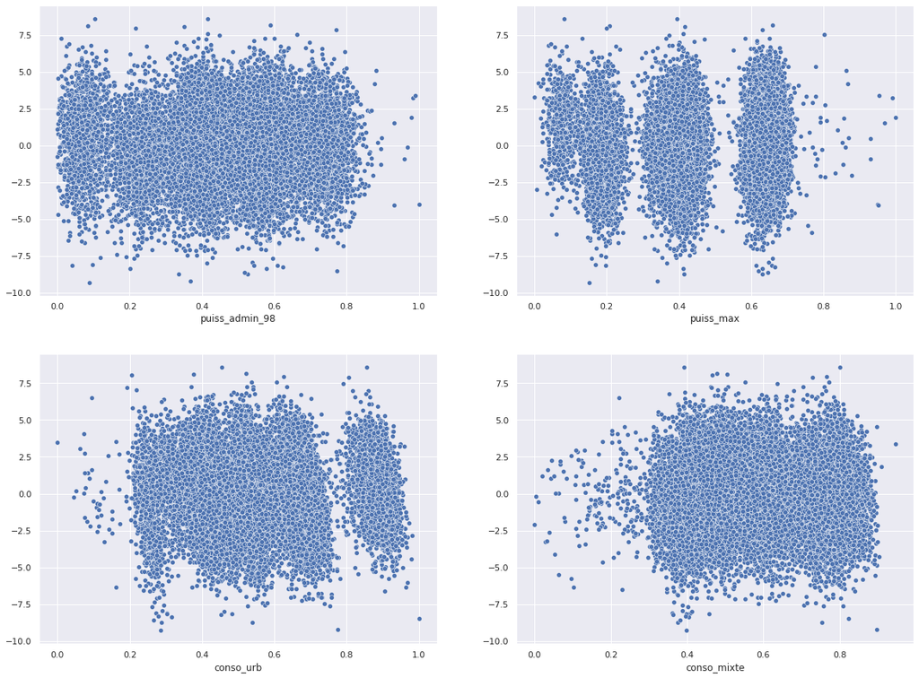

```python
fig, ax = plt.subplots(nrows = 2, ncols= 2, figsize=(20, 15))

# 'ax' assigs axes object to draw the plot onto
for variable, subplot in zip(X_train.columns[1:5], ax.flatten()):
    sns.scatterplot(X_train[variable], MLR_model2.resid , ax=subplot)

plt.show()
```

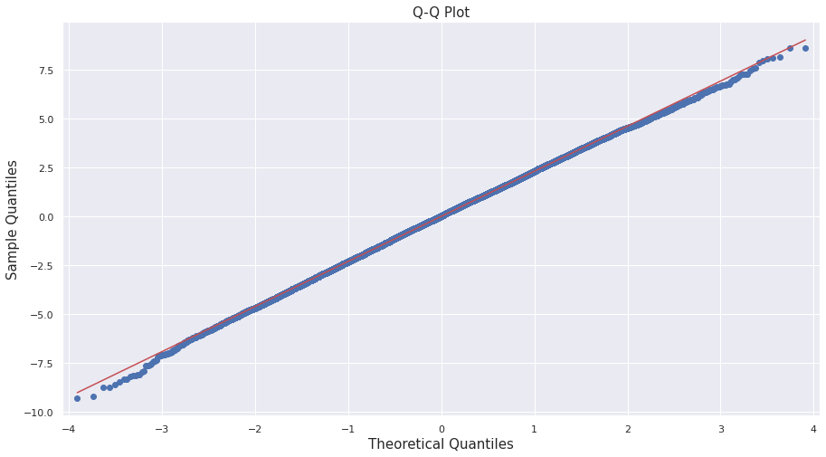

```python
plt.rcParams['figure.figsize'] = [15,8]

qqplot(MLR_model2.resid, line = 'r')

plt.title('Q-Q Plot', fontsize = 15)
plt.xlabel('Theoretical Quantiles', fontsize = 15)
plt.ylabel('Sample Quantiles', fontsize = 15)

plt.show()
```

```python
###7. Model Evaluation

##7.1 Measures of Variation

###8. Model Performance
```

```python
train_pred = MLR_model2.predict(X_train)
test_pred = MLR_model2.predict(X_test)
```

## 8.1 Mean Squared Error (MSE)

```python
mse_train = round(mean_squared_error(y_train, train_pred),4)
mse_test = round(mean_squared_error(y_test, test_pred),4)

print("Mean Squared Error (MSE) on training set: ", mse_train)
print("Mean Squared Error (MSE) on test set: ", mse_test)
```

```
Mean Squared Error (MSE) on training set:  5.3147
Mean Squared Error (MSE) on test set:  5.3625
```

## 8.2 Root Mean Squared Error (RMSE)

```python
mse_train = mean_squared_error(y_train, train_pred)
rmse_train = round(np.sqrt(mse_train), 4)

mse_test = mean_squared_error(y_test, test_pred)
rmse_test = round(np.sqrt(mse_test), 4)

print("Root Mean Squared Error (RMSE) on training set: ", rmse_train)
print("Root Mean Squared Error (RMSE) on test set: ", rmse_test)
```

```
Root Mean Squared Error (RMSE) on training set:  2.3054
Root Mean Squared Error (RMSE) on test set:  2.3157
```

## 8.3Mean Absolute Error (MAE)

```python
mae_train = round(mean_absolute_error(y_train, train_pred),4)
mae_test = round(mean_absolute_error(y_test, test_pred),4)


print("Mean Absolute Error (MAE) on training set: ", mae_train)
print("Mean Absolute Error (MAE) on test set: ", mae_test)
```

```
Mean Absolute Error (MAE) on training set:  1.8407
Mean Absolute Error (MAE) on test set:  1.8505
```

## 8.4 R2

```python
print("r2 score",metrics.r2_score(y_train, train_pred))
```

```
r2 score 0.9680296328442788
```

```python
###9. Model Optimization
```

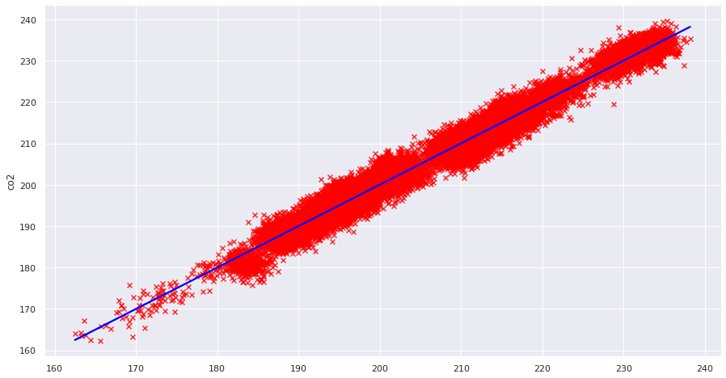

```python
sns.regplot(y = y_train,x = train_pred,color='red',line_kws={'color':'blue'},marker='x')
plt.show()
```